# Assignment 2: Regression and model validation

*Describe the work you have done this week and summarize your learning.*

- Describe your work and results clearly.
- Assume the reader has an introductory course level understanding of writing and reading R code as well as statistical methods.
- Assume the reader has no previous knowledge of your data or the more advanced methods you are using.

```r
date()
```

```
## [1] "Mon Nov 14 21:24:31 2022"
```

## Libraries

```r
library(psych)
```

## Reading the data

```r
setwd("C:/LocalData/salailja/IODS/IODS-project")
lrn14_sub <- read.csv("data/lrn14_sub.csv", sep=",", header=TRUE)
dim(lrn14_sub)
```

```
## [1] 166   7
```

```r
str(lrn14_sub)
```

```
## 'data.frame':    166 obs. of  7 variables:
##  $ gender  : chr  "F" "M" "F" "M" ...
##  $ age     : int  53 55 49 53 49 38 50 37 37 42 ...
##  $ attitude: num  3.7 3.1 2.5 3.5 3.7 3.8 3.5 2.9 3.8 2.1 ...
##  $ deep    : num  3.58 2.92 3.5 3.5 3.67 ...
##  $ stra    : num  3.38 2.75 3.62 3.12 3.62 ...
##  $ surf    : num  2.58 3.17 2.25 2.25 2.83 ...
##  $ points  : int  25 12 24 10 22 21 21 31 24 26 ...
```

```r
lrn14_sub$gender <- as.factor(lrn14_sub$gender)
```

The dataset used here is part of larger dataset that consists of questions regarding learning approaches. It consists of 7 variables: 2 demographic (gender, age), 3 measuring learning approaches (deep learning, surface learning, strategic learning), attitude towards statistics, and exam points in a statistics course. Learning approach variables and attitude are combination variables averaged from multiple questions measuring the same dimension. When dropping rows with 0 exam points, there is total of 166 observations. Gender is character type and is changed to factor type due to upcoming analyses. Other variables are integer or numeric type.

## Graphical overview of the data

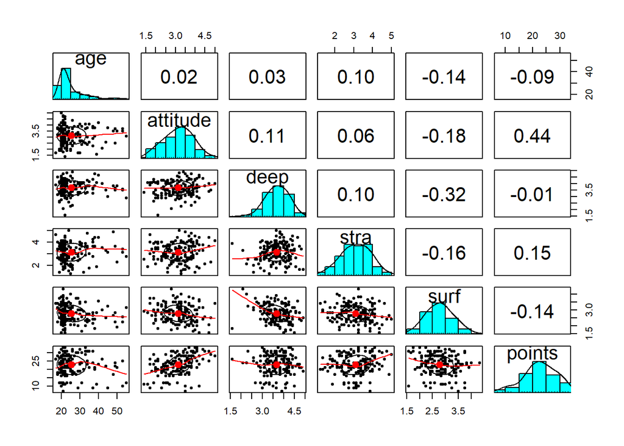

```r
pairs.panels(lrn14_sub[-1])
```

```r
summary(lrn14_sub)
```

```
##  gender       age           attitude          deep            stra
##  F:110   Min.   :17.00   Min.   :1.400   Min.   :1.583   Min.   :1.250
##  M: 56   1st Qu.:21.00   1st Qu.:2.600   1st Qu.:3.333   1st Qu.:2.625
##          Median :22.00   Median :3.200   Median :3.667   Median :3.188
##          Mean   :25.51   Mean   :3.143   Mean   :3.680   Mean   :3.121
##          3rd Qu.:27.00   3rd Qu.:3.700   3rd Qu.:4.083   3rd Qu.:3.625
##          Max.   :55.00   Max.   :5.000   Max.   :4.917   Max.   :5.000
##       surf           points
##  Min.   :1.583   Min.   : 7.00
##  1st Qu.:2.417   1st Qu.:19.00
##  Median :2.833   Median :23.00
##  Mean   :2.787   Mean   :22.72
##  3rd Qu.:3.167   3rd Qu.:27.75
##  Max.   :4.333   Max.   :33.00
```

Here, distributions and relationships between variables can be seen in graphical way (gender excluded, because of its categorical nature). Based on visual inspection, distributions are relatively close to normal, except age, which is clearly right-skewed. All relationships look quite linear, indicating that linear model is suitable here. Correlations between variables are from non-existent (deep vs. points = -0.01) to moderate (attitude vs. points = 0.44).

Also basic summary statistics regarding variables are provided. From here we can inspect that median age for participants is 22 years and the data consists of 110 females and 56 males.

## Fitting multiple regression model

I selected attitude as explaining variable because of its highest correlation with exam points. In addition I included gender and age as to the model to see if demographic variables have any statistical relationship to exam points.

```r
model1 <- lm(points ~ gender + age + attitude, data = lrn14_sub)
summary(model1)
```

```
##
## Call:
## lm(formula = points ~ gender + age + attitude, data = lrn14_sub)
##
## Residuals:
##      Min       1Q   Median       3Q      Max
## -17.4590  -3.3221   0.2186   4.0247  10.4632
##
## Coefficients:
##             Estimate Std. Error t value Pr(>|t|)
## (Intercept) 13.42910    2.29043   5.863 2.48e-08 ***
## genderM     -0.33054    0.91934  -0.360    0.720
## age         -0.07586    0.05367  -1.414    0.159
## attitude     3.60657    0.59322   6.080 8.34e-09 ***
## ---
## Signif. codes:  0 '***' 0.001 '**' 0.01 '*' 0.05 '.' 0.1 ' ' 1
##
## Residual standard error: 5.315 on 162 degrees of freedom
## Multiple R-squared:  0.2018, Adjusted R-squared:  0.187
## F-statistic: 13.65 on 3 and 162 DF,  p-value: 5.536e-08
```

The first fitted model had only one statistically significant explanatory variable, attention. Gender and age had no statistically significant relationship to exam points (p-values clearly over 0.05). Therefore, second model were created where the variable with weakest relationship to exam points (gender) was dropped.

```r
model2 <- lm(points ~ age + attitude, data = lrn14_sub)
summary(model2)
```

```
##
## Call:
## lm(formula = points ~ age + attitude, data = lrn14_sub)
##
## Residuals:
##      Min       1Q   Median       3Q      Max
## -17.3354  -3.3095   0.2625   4.0005  10.4911
##
## Coefficients:
##             Estimate Std. Error t value Pr(>|t|)
## (Intercept) 13.57244    2.24943   6.034 1.04e-08 ***
## age         -0.07813    0.05315  -1.470    0.144
## attitude     3.54392    0.56553   6.267 3.17e-09 ***
## ---
## Signif. codes:  0 '***' 0.001 '**' 0.01 '*' 0.05 '.' 0.1 ' ' 1
##
## Residual standard error: 5.301 on 163 degrees of freedom
## Multiple R-squared:  0.2011, Adjusted R-squared:  0.1913
## F-statistic: 20.52 on 2 and 163 DF,  p-value: 1.125e-08
```

As we can see from the results, dropping gender out from the model did not change much the results regarding age, which is still not even close to statistical significance (p = 0.144). Thus, age was also dropped and third model was created with only attention as explanatory variable.

```r
model3 <- lm(points ~ attitude, data = lrn14_sub)
summary(model3)
```

```
##
## Call:
## lm(formula = points ~ attitude, data = lrn14_sub)
##
## Residuals:
##      Min       1Q   Median       3Q      Max
## -16.9763  -3.2119   0.4339   4.1534  10.6645
##
## Coefficients:
##             Estimate Std. Error t value Pr(>|t|)
## (Intercept)  11.6372     1.8303   6.358 1.95e-09 ***
## attitude      3.5255     0.5674   6.214 4.12e-09 ***
## ---
## Signif. codes:  0 '***' 0.001 '**' 0.01 '*' 0.05 '.' 0.1 ' ' 1
##
## Residual standard error: 5.32 on 164 degrees of freedom
## Multiple R-squared:  0.1906, Adjusted R-squared:  0.1856
## F-statistic: 38.61 on 1 and 164 DF,  p-value: 4.119e-09
```

Here we can see our final model with only one explanatory variable, attention towards statistics. It has clear statistical relationship to exam points with very low p-value. In addition, seen from R-squared values of the model, attention towards statistics is able to explain around 19 % of the variance in exam points. This is not surprising, because it was expected that attention towards statistics is somehow related to statistics exam scores.

## Diagnostic plots

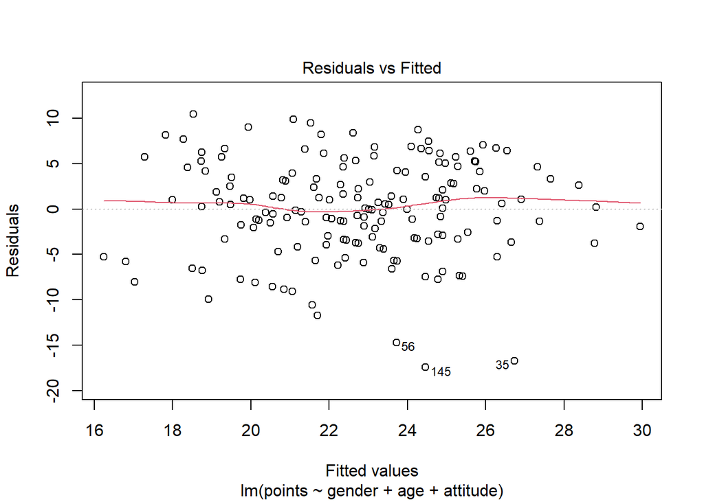

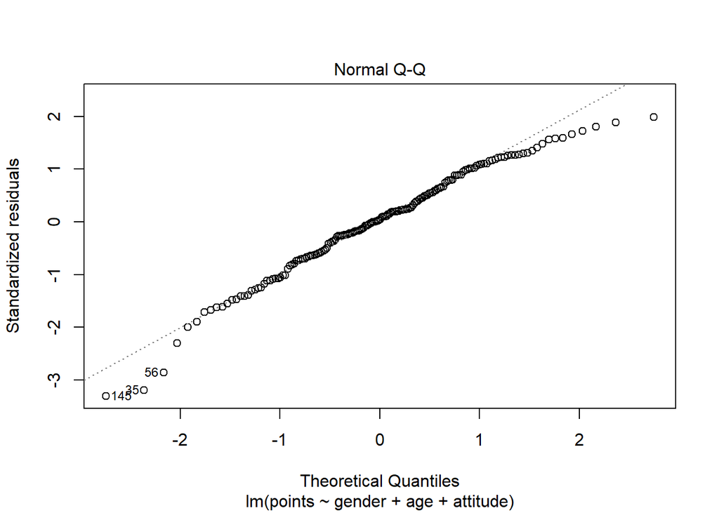

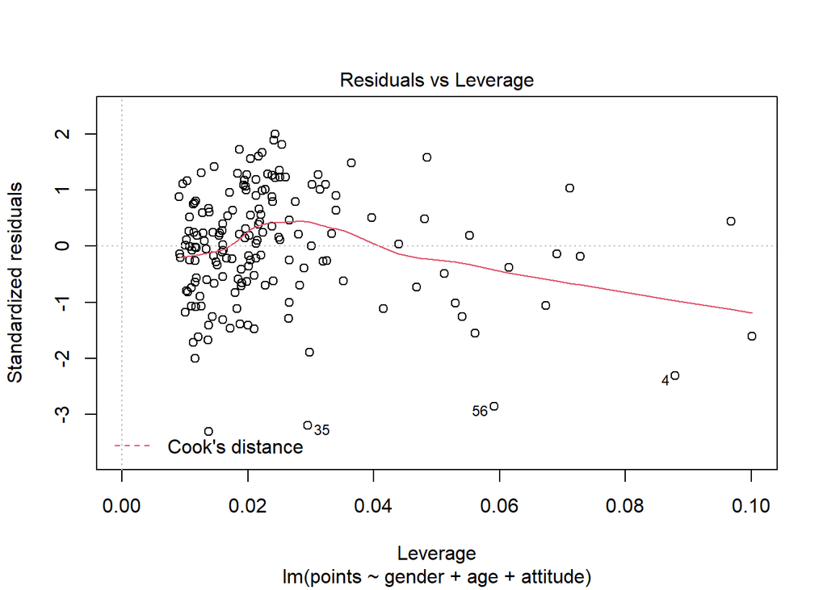

```r
plot(model1, which = c(1,2,5))
```